# Actividad R - UNIR

### Ejercicio 1: Inspección y Limpieza Inicial

1. **Inspección básica**: Realiza un resumen estadístico y estructural del dataset con `summary(bikes)` y `str(bikes)`.

```r
# Inspección básica
summary(bikes)
```

```
##        ID        Marital.Status        Gender              Income
##  Min.   :11000   Length:1000        Length:1000        Min.   : 10000
##  1st Qu.:15291   Class :character   Class :character   1st Qu.: 30000
##  Median :19744   Mode  :character   Mode  :character   Median : 60000
##  Mean   :19966                                         Mean   : 56268
##  3rd Qu.:24471                                         3rd Qu.: 70000
##  Max.   :29447                                         Max.   :170000
##                                                        NA's   :6
##     Children     Education          Occupation         Home.Owner
##  Min.   :0.00   Length:1000        Length:1000        Length:1000
##  1st Qu.:0.00   Class :character   Class :character   Class :character
##  Median :2.00   Mode  :character   Mode  :character   Mode  :character
##  Mean   :1.91
##  3rd Qu.:3.00
##  Max.   :5.00
##  NA's   :8
##       Cars       Commute.Distance      Region               Age
##  Min.   :0.000   Length:1000        Length:1000        Min.   :25.00
##  1st Qu.:1.000   Class :character   Class :character   1st Qu.:35.00
##  Median :1.000   Mode  :character   Mode  :character   Median :43.00
##  Mean   :1.455                                         Mean   :44.18
##  3rd Qu.:2.000                                         3rd Qu.:52.00
##  Max.   :4.000                                         Max.   :89.00
##  NA's   :9                                             NA's   :8
##  Purchased.Bike
##  Length:1000
##  Class :character
##  Mode  :character
##
##
##
##
```

```r
str(bikes)
```

```
## 'data.frame':    1000 obs. of  13 variables:
##  $ ID              : int  12496 24107 14177 24381 25597 13507 27974 19364 22155 19280 ...
##  $ Marital.Status  : chr  "Married" "Married" "Married" "Single" ...
##  $ Gender          : chr  "Female" "Male" "Male" "" ...
##  $ Income          : int  40000 30000 80000 70000 30000 10000 160000 40000 20000 NA ...
##  $ Children        : int  1 3 5 0 0 2 2 1 2 2 ...
##  $ Education       : chr  "Bachelors" "Partial College" "Partial College" "Bachelors" ...
##  $ Occupation      : chr  "Skilled Manual" "Clerical" "Professional" "Professional" ...
##  $ Home.Owner      : chr  "Yes" "Yes" "No" "Yes" ...
##  $ Cars            : int  0 1 2 1 0 0 4 0 2 1 ...
##  $ Commute.Distance: chr  "0-1 Miles" "0-1 Miles" "2-5 Miles" "5-10 Miles" ...
##  $ Region          : chr  "Europe" "Europe" "Europe" "Pacific" ...
##  $ Age             : int  42 43 60 41 36 50 33 43 58 NA ...
##  $ Purchased.Bike  : chr  "No" "No" "No" "Yes" ...
```

2. **Valores faltantes**: Identifica y cuenta los valores faltantes por columna.

```r
# Valores faltantes
missing_values <- sum(is.na(bikes))
```

3. **Eliminación de filas con valores faltantes**: Elimina las filas que contengan valores faltantes en cualquier columna.

```r
# Eliminación de filas con valores faltantes
# Eliminar datos es una tarea que requiete atención, puede que al borrar pierdas mucha información.
bikes_cn <- na.omit(bikes)
head(bikes_cn)
```

|  | ID | Marital.Status | Gender | Income | Children | Education | Occupation | Home.Owner | Cars | Commute.Distance | Region | Age | Purchased.Bike |
| --- | --- | --- | --- | --- | --- | --- | --- | --- | --- | --- | --- | --- | --- |
| 1 | 12496 | Married | Female | 40000 | 1 | Bachelors | Skilled Manual | Yes | 0 | 0-1 Miles | Europe | 42 | No |
| 2 | 24107 | Married | Male | 30000 | 3 | Partial College | Clerical | Yes | 1 | 0-1 Miles | Europe | 43 | No |
| 3 | 14177 | Married | Male | 80000 | 5 | Partial College | Professional | No | 2 | 2-5 Miles | Europe | 60 | No |
| 4 | 24381 | Single |  | 70000 | 0 | Bachelors | Professional | Yes | 1 | 5-10 Miles | Pacific | 41 | Yes |
| 5 | 25597 | Single | Male | 30000 | 0 | Bachelors | Clerical | No | 0 | 0-1 Miles | Europe | 36 | Yes |
| 6 | 13507 | Married | Female | 10000 | 2 | Partial College | Manual | Yes | 0 | 1-2 Miles | Europe | 50 | No |

### Ejercicio 2: Datos Faltantes Avanzados

1. **Imputación de valores faltantes**: Para una columna numérica con valores faltantes, imputa los valores faltantes con la media o mediana de la columna.

```r
# Imputación de valores faltantes
bikes$Age[is.na(bikes$Age)] <- mean(bikes$Age, na.rm = TRUE)
```

2. **Creación de una variable indicadora de datos faltantes**: Crea una nueva variable binaria que indique con `1` si falta un valor en una columna específica y `0` si no.

```r
# Creación de una variable indicadora de datos faltantes
bikes$Age_missing <- ifelse(is.na(bikes$Age), 1, 0)
```

### Ejercicio 3: Transformación y Creación de Variables

1. **Normalización de variables numéricas**: Selecciona una columna numérica y aplícale una normalización min-max.

```r
# Normalización de variables numéricas (ejemplo con 'age')
bikes$Age_normalized <- (bikes$Age - min(bikes$Age)) / (max(bikes$Age) - min(bikes$Age))
```

2. **Creación de una variable categórica**: A partir de una variable numérica, crea una nueva variable categórica (por ejemplo, grupos de edad basados en una columna de edad).

```r
# Creación de una variable categórica a partir de numérica
bikes$Age_categorical <- cut(bikes$Age, breaks=c(0, 18, 35, 65, 100), labels=c("Young", "Young adult", "Adult", "Senior"))
```

### Ejercicio 4: Manejo de Variables Categóricas

1. **Conversión de variables categóricas a numéricas**: Convierte una variable categórica en numérica usando `factor()` y luego `as.numeric()`.

```r
# Conversión de categóricas a numéricas
bikes$Occupation_Numeric <- as.numeric(factor(bikes$Occupation))
```

2. **Agrupación de categorías poco frecuentes**: Agrupa en una nueva categoría llamada “Otros” aquellas categorías que aparezcan menos de un umbral específico.

```r
# Agrupación de categorías poco frecuentes
bikes$Education_categorical <- fct_lump_n(bikes$Education, n = 5)
```

### Ejercicio 5: Visualización de Datos

1. **Histograma de una variable numérica**: Crea un histograma para una variable numérica.

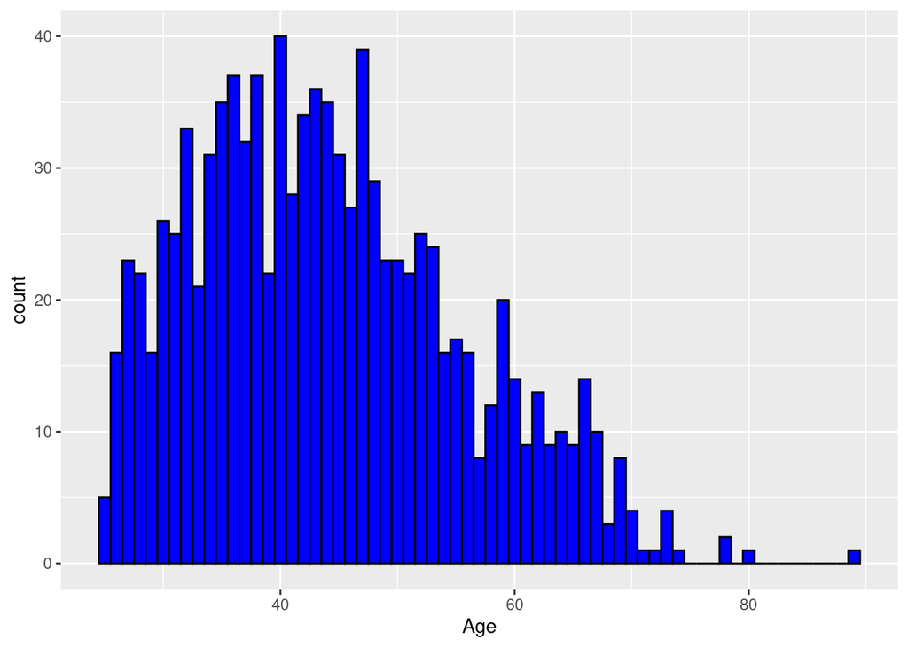

```r
# Histograma de una variable numérica
ggplot(bikes, aes(x = Age)) + geom_histogram(binwidth = 1, fill = "blue", color = "black")
```

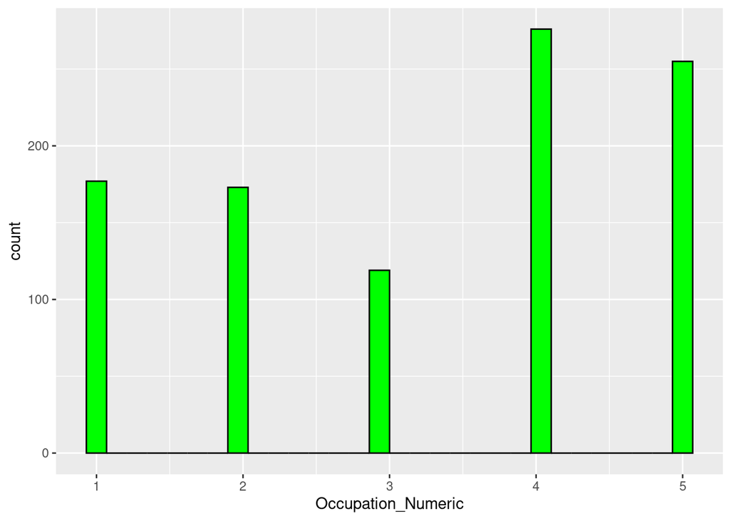

```r
ggplot(bikes, aes(x = Occupation_Numeric)) + geom_histogram(fill = "green", color = "black")
```

2. **Diagrama de barras para una variable categórica**: Crea un diagrama de barras para mostrar la frecuencia de las categorías de una variable categórica.

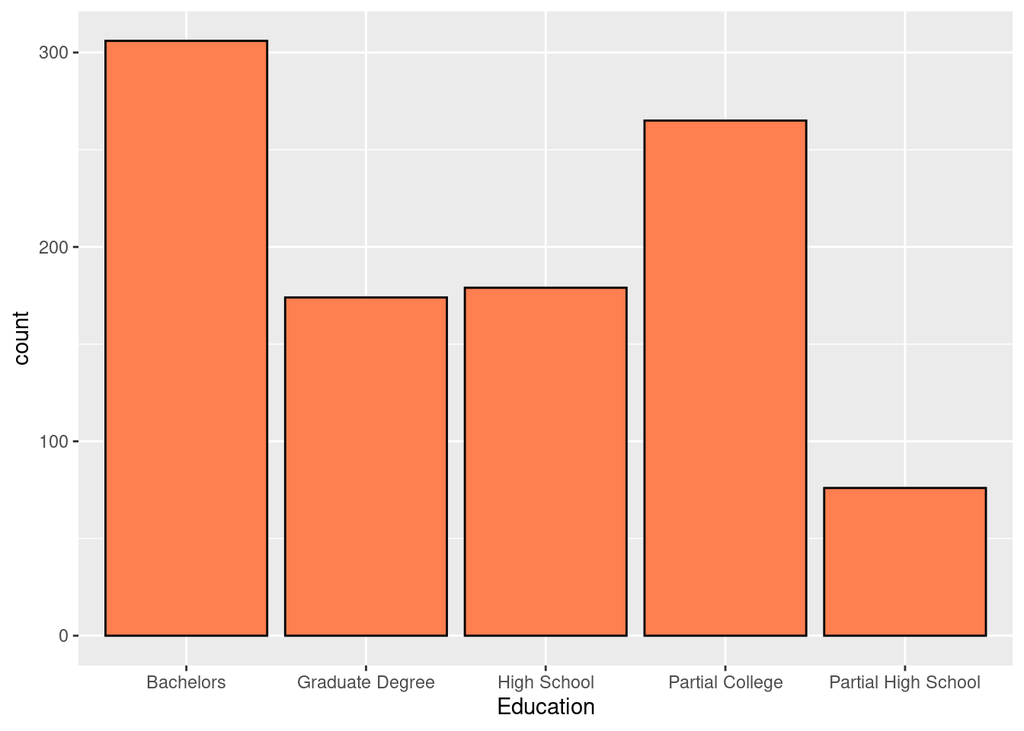

```r
# Diagrama de barras para una variable categórica
ggplot(bikes, aes(x = Education)) + geom_bar(fill = "coral", color = "black")
```

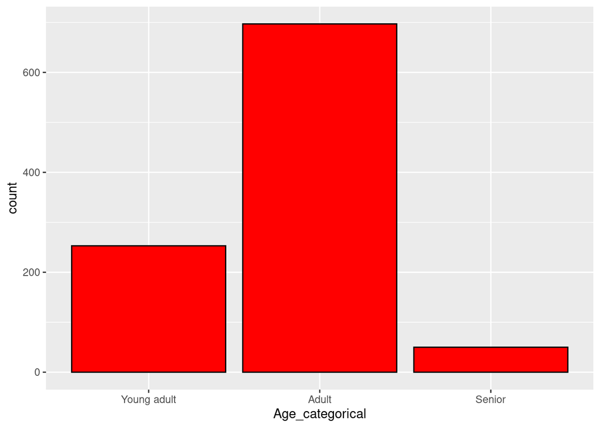

```r
# Diagrama de barras para una variable categórica
ggplot(bikes, aes(x = Age_categorical)) + geom_bar(fill = "red", color = "black")
```

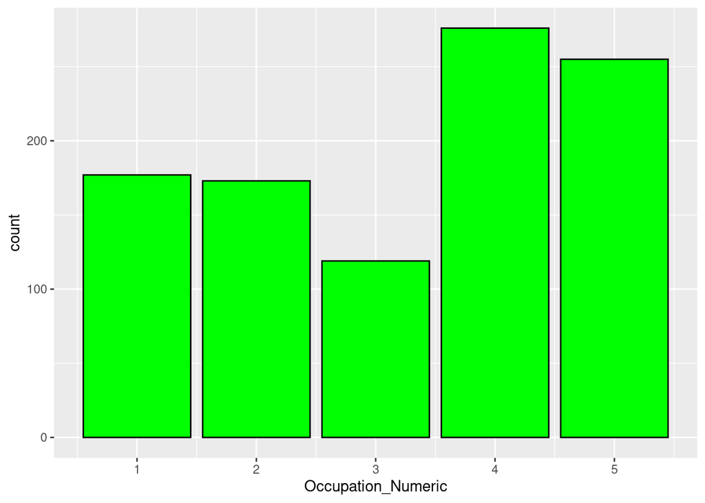

```r
ggplot(bikes, aes(x = Occupation_Numeric)) + geom_bar(fill = "green", color = "black")
```

##### Otros ejercicios de visualización

1. **Graficar la distribución de los ingresos de los compradores de bicicletas**.

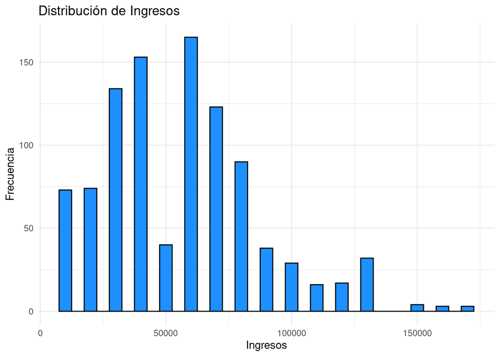

```r
ggplot(data = bikes, aes(x = Income)) +
  geom_histogram(binwidth = 5000, fill = "dodgerblue", color = "black") +
  theme_minimal() +
  labs(title = "Distribución de Ingresos", x = "Ingresos", y = "Frecuencia")
```

2. **Crear un diagrama de caja para comparar la distribución de edades entre géneros.**

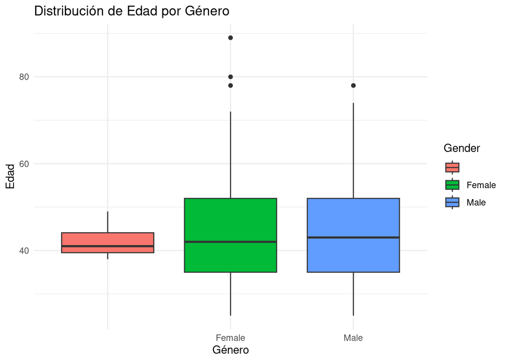

```r
ggplot(data = bikes, aes(x = Gender, y = Age, fill = Gender)) +
  geom_boxplot() +
  theme_minimal() +
  labs(title = "Distribución de Edad por Género", x = "Género", y = "Edad")
```

3. **Mostrar el número medio de autos que poseen los individuos agrupados por su estado civil.**

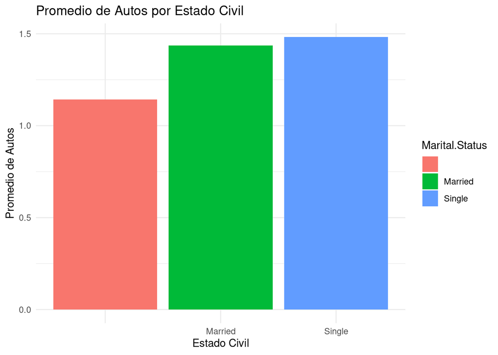

```r
# library(dplyr)
bikes %>%
  group_by(Marital.Status) %>%
  summarise(Average.Cars = mean(Cars, na.rm = TRUE)) %>%
  ggplot(aes(x = Marital.Status, y = Average.Cars, fill = Marital.Status)) +
    geom_col() +
    theme_minimal() +
    labs(title = "Promedio de Autos por Estado Civil", x = "Estado Civil", y = "Promedio de Autos")
```

4. **Visualizar la frecuencia de los niveles educativos entre los compradores de bicicletas.**

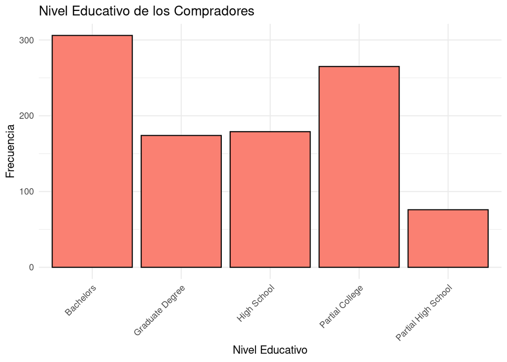

```r
# library(dplyr)
ggplot(data = bikes, aes(x = Education)) +
  geom_bar(fill = "salmon", color = "black") +
  theme_minimal() +
  theme(axis.text.x = element_text(angle = 45, hjust = 1)) +
  labs(title = "Nivel Educativo de los Compradores", x = "Nivel Educativo", y = "Frecuencia")
```

5. **Explorar la relación entre la edad y los ingresos de los compradores de bicicletas con un gráfico de dispersión.**

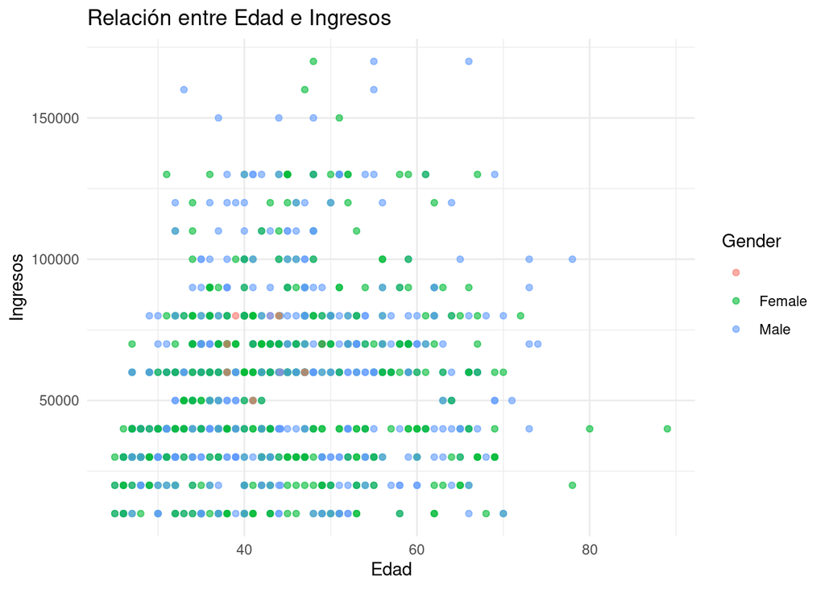

```r
# library(dplyr)
ggplot(data = bikes, aes(x = Age, y = Income, color = Gender)) +
  geom_point(alpha = 0.6) +
  theme_minimal() +
  labs(title = "Relación entre Edad e Ingresos", x = "Edad", y = "Ingresos")
```

### Comprensión de los datos: realiza cálculos y obtén información útil.

1. **Calcular el ingreso promedio de los compradores de bicicletas.**

```r
# Calcula el ingreso promedio
ingreso_promedio <- mean(bikes$Income, na.rm = TRUE)
print(paste("El ingreso promedio es:", ingreso_promedio))
```

```
## [1] "El ingreso promedio es: 56267.6056338028"
```

2. **Calcular el ingreso medio por cada nivel educativo.**

```r
# library(dplyr)

# Agrupa por nivel educativo y calcula el ingreso medio
ingreso_medio_educacion <- bikes %>%
  group_by(Education) %>%
  summarise(Ingreso_Medio = mean(Income, na.rm = TRUE))

print(ingreso_medio_educacion)
```

```
## # A tibble: 5 × 2
##   Education           Ingreso_Medio
##   <chr>                       <dbl>
## 1 Bachelors                  63026.
## 2 Graduate Degree            66092.
## 3 High School                47022.
## 4 Partial College            54504.
## 5 Partial High School        34474.
```

3. **Encontrar la correlación entre el número de autos y el número de hijos** que tienen los compradores de bicicletas.

```r
# Calcula la correlación entre Cars y Children
correlacion_cars_children <- cor(bikes$Cars, bikes$Children, use = "complete.obs")
print(paste("La correlación entre el número de autos y el número de hijos es:", correlacion_cars_children))
```

```
## [1] "La correlación entre el número de autos y el número de hijos es: 0.280242698463222"
```

## Retos Propuestos

Después del análisis anterior, realiza los siguientes retos.

En cada reto, debes editar el formato de la celda para que permita la ejecución de código R. Esta edición implica cambiar las cabeceras de las celdas por ```{r}.

**Reto 1**. Completar el código para calcular y comparar la edad media entre los compradores de bicicletas y los que no compraron.

```r
# library(dplyr)

# Código a completar
edad_media_compradores <- bikes %>%
  filter(Purchased.Bike == "Yes") %>%
  summarise(Edad_Media = mean(Age, na.rm = TRUE))

edad_media_no_compradores <- bikes %>%
  filter(Purchased.Bike == "No") %>%
  summarise(Edad_Media = mean(Age, na.rm = TRUE))

print(edad_media_compradores)
```

```
##   Edad_Media
## 1   42.93082
```

```r
print(edad_media_no_compradores)
```

```
##   Edad_Media
## 1   45.34051
```

**Reto 2**. Calcular el número promedio de hijos que tienen los compradores de bicicletas, agrupado por región.

```r
# Código a completar
promedio_hijos_region <- bikes %>%
  group_by(Region) %>%
  summarise(Promedio_Hijos = mean(Children, na.rm = TRUE))

print(promedio_hijos_region)
```

```
## # A tibble: 3 × 2
##   Region        Promedio_Hijos
##   <chr>                  <dbl>
## 1 Europe                  1.60
## 2 North America           2.14
## 3 Pacific                 1.79
```

**Reto 3**. Calcular la diferencia de ingresos promedio entre géneros.

```r
# library(dplyr)

# Código a completar
ingresos_por_genero <- bikes %>%
  group_by(Gender) %>%
  summarise(Ingreso_Medio = mean(Income, na.rm = TRUE))

diferencia_ingresos <- diff(ingresos_por_genero$Ingreso_Medio)

print(diferencia_ingresos)
```

```
## [1] -14429.718   2899.293
```

**Reto 4**. Filtra el dataset para incluir solo a aquellos con un ingreso superior a $50,000. Calcula y compara el número de personas que compraron y no compraron bicicletas en este grupo de ingresos.

```r
# Ajusta este umbral según necesites
umbral_ingresos <- 50000

compradores_filtrados <- bikes %>%
  filter(Income > umbral_ingresos) %>%
  group_by(Purchased.Bike) %>%
  summarise(Count = n())

print(compradores_filtrados)
```

```
## # A tibble: 2 × 2
##   Purchased.Bike Count
##   <chr>          <int>
## 1 No               266
## 2 Yes              254
```

**Reto 5**. Crea una nueva variable categórica basada en la edad, dividiendo a los compradores en grupos de “Joven”, “Mediana Edad” y “Senior”. Luego, visualiza la distribución de estos grupos de edad entre quienes compraron y no compraron bicicletas.

- Crea la nueva variable de grupo de edad basada en la edad: 0-29 años (“Joven”), 30-59 (“Mediana Edad”), 60+ (“Senior”).
- Usa ggplot2 para crear un gráfico de barras que muestre la cantidad de compradores y no compradores en cada grupo de edad.

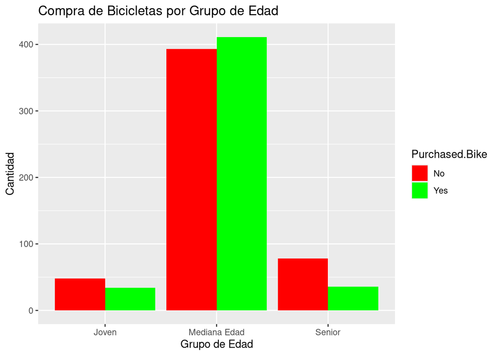

```r
bikes$Age_Group <- cut(bikes$Age, breaks = c(0, 29, 59, Inf),
                             labels = c("Joven", "Mediana Edad", "Senior"))

ggplot(bikes, aes(x = Age_Group, fill = Purchased.Bike)) +
  geom_bar(position = "dodge") +
  labs(title = "Compra de Bicicletas por Grupo de Edad", x = "Grupo de Edad", y = "Cantidad") +
  scale_fill_manual(values = c("No" = "red", "Yes" = "green"))
```

**Reto 6**. Evalúa la correlación entre el número de autos y el ingreso de los compradores de bicicletas. Ajusta el dataset para incluir solo compradores o no compradores y compara las correlaciones.

- Calcula la correlación entre el número de autos y el ingreso para todo el dataset.
- Repite el cálculo de correlación, pero separa el dataset entre quienes compraron y quienes no compraron bicicletas. Compara estas correlaciones.

```r
# Correlación para todo el dataset
cor_total <- cor(bikes$Cars, bikes$Income, use = "complete.obs")

# Correlación para compradores
cor_compradores <- cor(bikes[bikes$Purchased.Bike == "Yes",]$Cars,
                       bikes[bikes$Purchased.Bike == "Yes",]$Income, use = "complete.obs")

# Correlación para no compradores
cor_no_compradores <- cor(bikes[bikes$Purchased.Bike == "No",]$Cars,
                       bikes[bikes$Purchased.Bike == "No",]$Income, use = "complete.obs")

print(cor_total)
```

```
## [1] 0.4399799
```

```r
print(cor_compradores)
```

```
## [1] 0.4579424
```

```r
print(cor_no_compradores)
```

```
## [1] 0.4608257
```

Estos ejercicios te habrán permitido prácticar la limpieza de datos y preparación para análisis posteriores, abordando problemas comunes y técnicas esenciales para cualquier proyecto de ciencia de datos.